# F3.3: il simulatore di oggi regge fuori dalle aree su cui è stato tarato?

geo_spatialtrans, report di step (protocollo v2)

Published

November 19, 2026

# In breve: il simulatore di oggi regge fuori dalle aree su cui è stato tarato?

**A cosa serviva.** Per ogni tessuto il simulatore è tarato su 5 aree di una sola sezione, le stesse su cui finora lo abbiamo verificato. Qui lo abbiamo misurato, senza toccarlo, su 38 aree vere mai usate: aree nuove delle stesse sezioni, e aree di altri pazienti e di altre sezioni. Abbiamo usato gli stessi due metodi di analisi della prima prova, bin2cell e RCTD. Il margine è quello della prima prova: quanto varia ogni misura fra le aree vere di taratura dello stesso tessuto. Volevamo distinguere due difetti. Il primo: il simulatore va bene solo sulle aree di taratura, cioè è sovradattato. Il secondo: sbaglia ovunque allo stesso modo perché gli manca la variabilità.

**Cosa abbiamo trovato.**

1. **Dentro la stessa sezione non vediamo sovradattamento, ma con così poche aree vedremmo solo scarti grandi.**
   - Sulle 15 aree nuove di intestino, tumore del colon, linfonodo, cervello e cuore, i valori veri restano dove stavano le aree di taratura, e il simulato non peggiora.
   - Con così poche aree, però, uno spostamento più piccolo di circa un margine non lo vedremmo.
   - I difetti trovati nella prima prova restano anche sulle aree nuove: 10 su 12. I due che mancano sono nel cervello, dove c’è una sola area nuova.
2. **Gli altri pazienti e le altre sezioni sono molto diversi dalla sezione di taratura, e lì il simulato peggiora di circa tre margini.**
   - La differenza più grande è la profondità. Nel tumore del colon i trascritti per cellula sono circa 1 100 nel paziente di taratura (il simulato ne ha altrettanti), 640 nel paziente 1, 2 000 nel paziente 5 e 270 nel tumore da 6,5 mm. Nella seconda sezione di cervello sono un terzo della prima.
   - Una delle conferme della prima prova era costruita dalla taratura: i trascritti per cellula tornavano perché il fattore di profondità era tarato su quelle aree. Nello stroma la conferma cade in 2 sezioni nuove su 3.
   - Con 3 pazienti non sappiamo separare quanto dipende dal paziente e quanto dalla sezione. Se aggiungiamo il tumore da 6,5 mm, la variabilità fra sezioni non è trascurabile rispetto a quella fra aree per 4 delle 12 combinazioni di misura e tessuto (trascritti per cellula e quadrati con un solo tipo nel tumore; quadrati con un solo tipo e vicini dello stesso tipo nello stroma).
3. **Nello stroma degli altri pazienti i tipi cellulari sono più mescolati che nel paziente di taratura, cioè più simili al simulato.**
   - Due quadrati vicini hanno lo stesso tipo nell’89 % dei casi nel paziente di taratura, nel 72-75 % nei pazienti 1 e 5, nel 65 % nel simulato.
   - Una parte di quello che chiamavamo difetto dello stroma è quindi propria del paziente di taratura. La semina a compartimenti rende i tipi più ordinati: potrebbe avvicinare il simulato a quel paziente e allontanarlo dagli altri.
4. **I controlli funzionano.**
   - Nel cuore, dove ci aspettiamo che il simulatore fallisca perché le cellule vere sono allungate, la differenza di orientamento resta anche sulle aree nuove (0,11, contro 0,10 dentro campione).
   - Un falso «fuori campione», fatto con le sole aree di taratura, non mostra alcuno spostamento.
   - Come previsto, solo 18 valori veri su 228 cadono dentro la variabilità delle aree simulate: il simulatore ha una sola composizione per tessuto.

**Cosa devi decidere.**

1. **Il prossimo passo resta la prova della semina a compartimenti? Consiglio di sì, giudicandola anche sullo stroma degli altri pazienti.**
   - Nelle stesse sezioni i difetti di disposizione dei tipi si confermano sulle aree nuove, e non c’è sovradattamento visibile: la disposizione resta la causa più grande che si può correggere senza dati nuovi.
   - Il punto 3 dice dove la prova può fallire, e va guardato.
   - Alternativa: prima lo step sulla variabilità fra sezioni e pazienti (profondità e composizione che cambiano da sezione a sezione). È lo scarto più grande fuori campione. Ma con 3 pazienti bisogna prima progettare cosa far variare e di quanto, e il compartimento resterebbe da provare.
2. **Un cambiamento del simulatore si giudica fuori campione rispetto al simulatore di oggi? Consiglio di sì.**
   - Oggi la regola dice: nessuna misura confermata sui dati di taratura può diventare smentita in più di una sezione. Il simulatore di oggi la viola già, per i trascritti per cellula nello stroma, a causa della profondità. Così com’è scritta, la regola boccerebbe ogni cambiamento, compresi i compartimenti, per un difetto che il cambiamento non tocca.
   - Proposta: un cambiamento si boccia se rende smentita fuori campione una misura che oggi lì regge, oppure se peggiora oltre il suo margine una misura già smentita.
   - Alternativa: lasciare la regola com’è. Allora prima bisogna far variare la profondità per sezione, altrimenti nessun cambiamento può passare.

**Comunque**

- Quando progetteremo la variabilità fra sezioni e pazienti partiremo da queste misure: profondità fino a 7 volte diversa fra sezioni dello stesso tumore, stroma più mescolato negli altri pazienti.
- I due tessuti nuovi, rene umano e fegato di ratto, restano sigillati per quando rivedremo lo spostamento dei trascritti. Gli altri gruppi di aree di verifica sono stati letti una volta: ne restano due letture ciascuno.
- Nel linfonodo il modo di contare i geni marcatori di due tipi cambia il confronto fra aree nuove e aree di taratura. Quando quella misura entrerà in una decisione, riporteremo i due conteggi.

Appena decidi questi 2 punti, lo step è chiuso.

# Dubbi rinviati

| cosa | perché | cosa serve per chiuderlo | step destinatario | voce di BACKLOG |
| --- | --- | --- | --- | --- |
| Gli altri pazienti e sezioni del tumore e del cervello differiscono dalla sezione di taratura di circa 2,4 margini (profondità fino a 7 volte, stroma più mescolato) | il simulatore ha una profondità e una composizione per tessuto, da una sezione | progettare quali grandezze variano per sezione e per paziente e stimarle su più sezioni | step della variabilità fra aree, sezioni e pazienti | BL-272 (con BL-262, BL-270) |
| La condizione 4 di R-3 boccia già il simulatore di oggi | i trascritti per cellula nello stroma, tarati su P2, sono smentiti in 2 sezioni | decisione di Luca (decisione 2 del riassunto) | questo step | nessuna |
| La semina a compartimenti potrebbe allontanare lo stroma simulato da quello degli altri pazienti | nei pazienti 1 e 5 lo stroma è più mescolato che in P2 | giudicare la prova dei compartimenti anche sullo stroma di P1 e P5 | prova della semina a compartimenti | BL-273 |

# Cancelli e previsioni

Pre-registrazione: cancelli e previsioni proposte `858a7cf`; ok di Luca sulle previsioni e sulle soglie del 2026-11-19, `eedd71a` («Ok, come proposte (Consigliato)»; tessuti nuovi «Lasciarli sigillati (Consigliato)»). Correzione della descrizione di M-5 prima della lettura: `66f9cc3`. Errore di pre-registrazione trovato dal cancello G-1 prima della lettura, decisione di Luca DEC-098; scelte tecniche DEC-097.

## Correzione dopo il cancello G-1

**Errore di pre-registrazione scoperto dal cancello G-1 (f)**, prima di ogni lettura dei dati di verifica: con uno spostamento costruito di 1 h, S* restituisce 0,557 invece di 1 (`results/F3.3/F3.3_G1_a_b_c_d_e_f.csv`). La correzione per il caso sottrae la distorsione che c’è sotto «nessuno spostamento», più grande di quella che c’è quando lo spostamento è grande. Per questo S* e G* sottostimano gli spostamenti grandi e possono dare «confermata» con uno spostamento vero di circa mezzo margine. Decisione di Luca: F3.3: spostamento e degrado con lo stimatore quadratico corretto (DEC-098).

- **Stimatori principali (sostituiscono S* e G* in P-1, P-2, P-3)**. Q_S = media su celle e insiemi di (D² − Var D) / h², con D = media vera fuori meno media vera dentro e Var D = s²(1/n_fuori + 1/n_dentro). Q_G = media sulle celle non smentite dentro campione di [(g_fuori² − Var g_fuori) − (g_dentro² − Var g_dentro)] / h². Tutte e due non distorte per il quadrato medio vero. Si riportano in unità di h come radice con segno. Intervallo: bootstrap parametrico (modello t con la deviazione standard combinata, B = 2 000, seme 20261119), percentile corretto per lo scarto della mediana. Prova sui dati sintetici: spostamenti costruiti di 0,5, 1 e 2 h stimati 0,49, 0,98-1,0 e 2,0 (`/tmp` e `results/F3.3/F3.3_prereg_precision_q.csv`).
- **Esiti** (stesso intervallo di rilevanza ±0,5 h). Smentita se l’intervallo sta tutto sopra 0,5. Altrimenti «non rilevato a questa profondità», mai «confermata»: con queste numerosità l’intervallo sotto nessuno spostamento va da circa −0,5 a +0,8 h, e una conferma è impossibile per costruzione. Precisione attesa, dai soli dati di taratura: uno spostamento vero di 1 h si stima fra 0,84 e 1,18 in L1 e fra 0,87 e 1,13 in L2 (95 % delle repliche).
- **S* e G* come scritti** si calcolano e si giudicano lo stesso, accanto, com’erano scritti.
- **Regola di decisione, lettura 1**: diventa «nessun sovradattamento rilevato a questa profondità»: P-1 e P-3 non smentite in L1, P-4 confermata. La conseguenza non cambia (prova della semina a compartimenti), ma nel riassunto si scrive che uno spostamento sotto circa 1 margine non si vede.
- Il cancello G-1 (f) si rifà con le prove degli stimatori nuovi: media sotto nessuno spostamento entro ±0,15 h² sul quadrato, spostamento di 1 h stimato entro 1 ± 0,25. La prova fallita di S* resta registrata.

Tabelle in `results/F3.3/`: `F3.3_summary.csv` (previsioni e controprove), `F3.3_cells.csv` (una riga per tessuto × misura × insieme), `F3.3_area_values.csv` (valori per area), `F3.3_varcomp.csv`, `F3.3_r4a.csv`, `F3.3_bridge_cg.csv`, `F3.3_cp2.csv`, `F3.3_sens_insd.csv`, `F3.3_bl264_a4.csv`, `F3.3_D1.csv`, `F3.3_D2.csv`. Figure in `reports/F3.3_parts/`. Calcolo: catena delle aree di verifica dal 2026-11-19 18:48 alle 20:50 (4 processi), riproducibilità circa 1 ora (2 processi).

### Cancelli

[output not shown]

### Previsioni

| id | quantità | atteso | osservato (intervallo) | esito |
| --- | --- | --- | --- | --- |
| P-1 | spostamento del vero, aree nuove della stessa sezione (30 celle) | circa 0 | −0,20 h (−0,81; 1,12) | non rilevato a questa profondità |
| P-2 | spostamento del vero, altre sezioni o pazienti (18 celle) | sopra 0,5 | 2,38 h (2,07; 2,73) | smentita (spostamento grande), come atteso |
| P-3 | degrado del simulato, L1 (18 celle non smentite dentro campione) | circa 0 | −0,19 h (−1,14; 1,21) | non rilevato a questa profondità |
| P-3 | degrado del simulato, L2 (8 celle) | sopra 0,5 | 2,94 h (2,33; 3,43) | smentita (degrado grande), come atteso |
| P-4 | persistenza dei giudizi smentiti, L1 | ≥ 0,8 | 10 su 12 (0,83) | confermata |
| P-4 | persistenza, L2 | ≥ 0,8 | 19 su 26 (0,73) | smentita |
| P-5 | condizione 4 di R-3, L1 | rispettata | 0 misure confermate diventano smentite | rispettata |
| P-5 | condizione 4 di R-3, L2 | violata | UMI per cellula nello stroma smentiti nel paziente 1 e nel tumore da 6,5 mm | violata, come atteso |
| P-6 | ρ fra pazienti e fra aree (P1, P2, P5) | indeterminato | 12 righe su 12 indeterminate; con il tumore da 6,5 mm, 4 su 12 sopra 0,5 (UMI per cellula e singoletti nel tumore, singoletti e vicini dello stesso tipo nello stroma) | come atteso con 3 pazienti |
| P-7 | aree vere di verifica dentro il 90 % centrale del simulato | ≤ 0,10 | 18 su 228 (0,079) | come atteso |

Statistiche scritte nella pre-registrazione, giudicate com’erano scritte (DEC-098, punto 3): S* L1 0,04 (−0,09; 0,16) confermata; G* L1 −0,01 (−0,23; 0,23) confermata; S* L2 1,46 (1,29; 1,59) smentita; G* L2 1,84 (1,39; 2,31) smentita. Gli esiti di L2 coincidono; in L1 le statistiche scritte «confermano» dove quelle corrette dicono «non rilevato»: è il difetto per cui sono state sostituite.

**Ponte dei geni comuni** (F3.3: scelte tecniche della misura fuori campione (DEC-097), punto 4): la restrizione ai 18 024 geni comuni alle quattro sezioni del tumore e al simulato (non 18 107 come in F3.2: là si contavano le matrici grezze) sposta le misure di P2 al più di 0,074 h (UMI per cellula nel tumore): il simulato resta quello di F3.1.

**Scomposizione descrittiva della tabella per cella** (non è un’indagine nuova: legge `F3.3_cells.csv`). In L2 il degrado sta nelle celle che dentro campione andavano bene: UMI assegnati (3,2 h) e UMI per cellula (2,6 h) nel tumore e nello stroma, concordanza con il nucleo nel cervello FFPE (4,4 h). I trascritti per cellula del tumore valgono 1 120 in P2, 640 in P1, 2 000 in P5, 270 nel tumore da 6,5 mm (simulato 1 096); nello stroma 663, 207, 567, 215 (simulato 653); nel cervello 4 514 nella sezione di taratura, 1 417 nella sezione FFPE. Fra i 7 giudizi smentiti che non restano tali in L2, 6 sono nello stroma degli altri pazienti (marcatori estranei, concordanza, vicini dello stesso tipo): lì il vero è più mescolato che in P2 e più vicino al simulato (vicini dello stesso tipo: P2 0,886, P1 0,752, P5 0,716, simulato 0,649; tumore da 6,5 mm 0,885).

### Controprove

- **CP-1, cuore: passata.** Anisotropia del campo degli UMI sulle 5 aree nuove, vero meno simulato 0,112 (errore standard 0,018), oltre 0,032 e oltre 2 errori standard (dentro campione 0,097). Negli altri tessuti, aree nuove: intestino 0,037, tumore 0,051, cervello −0,019 (il linfonodo non ha il valore simulato per i quarti).
- **CP-2, falso fuori campione: passata.** Media di S* sui 10 modi di dividere le aree di taratura in 3 + 2, sui cinque tessuti con 5 aree: 0,007 (per tessuto da −0,032 a 0,045). Interpretazione dichiarata prima del calcolo: criterio sulla media dei 10 modi, non su ognuno.

### Documentazione

- **D-1** (`F3.3_D1.csv`): per tessuto da 40 a 80 valori scalari e 5 tabelle del simulatore vengono dalle 5 aree di taratura, cioè da 5 unità indipendenti di una sola sezione.
- **D-2** (`F3.3_D2.csv`): dei 14 giudizi confermati di F3.1, 6 sono UMI per cellula, costruiti dal fattore di profondità tarato in S2.5 sull’UMI per quadratino delle stesse aree; 4 sono UMI assegnati, «in parte» (densità e taglia dei nuclei dalle stesse aree); 4 no. Fuori campione: gli UMI per cellula restano senza smentita in L1 (spostamenti da −0,9 a +0,3 h) e sono smentiti in 5 insiemi L2 su 7.

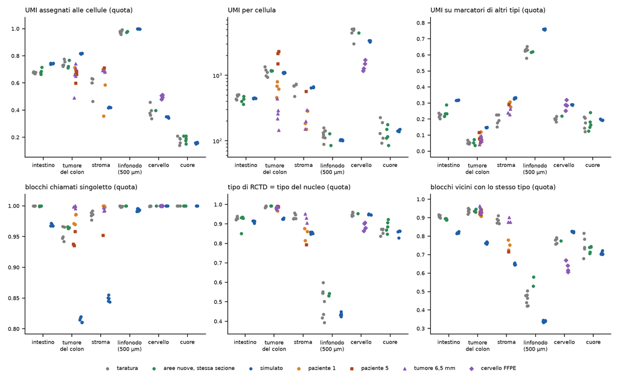

Valori per area delle sei misure dei metodi: taratura (grigio), aree nuove della stessa sezione (verde), altri pazienti e sezioni (arancio, rosso, viola), simulato (blu). **Cosa guardare**: i punti verdi stanno con i grigi; arancio, rosso e viola se ne allontanano, soprattutto negli UMI per cellula del tumore e nella seconda sezione di cervello.

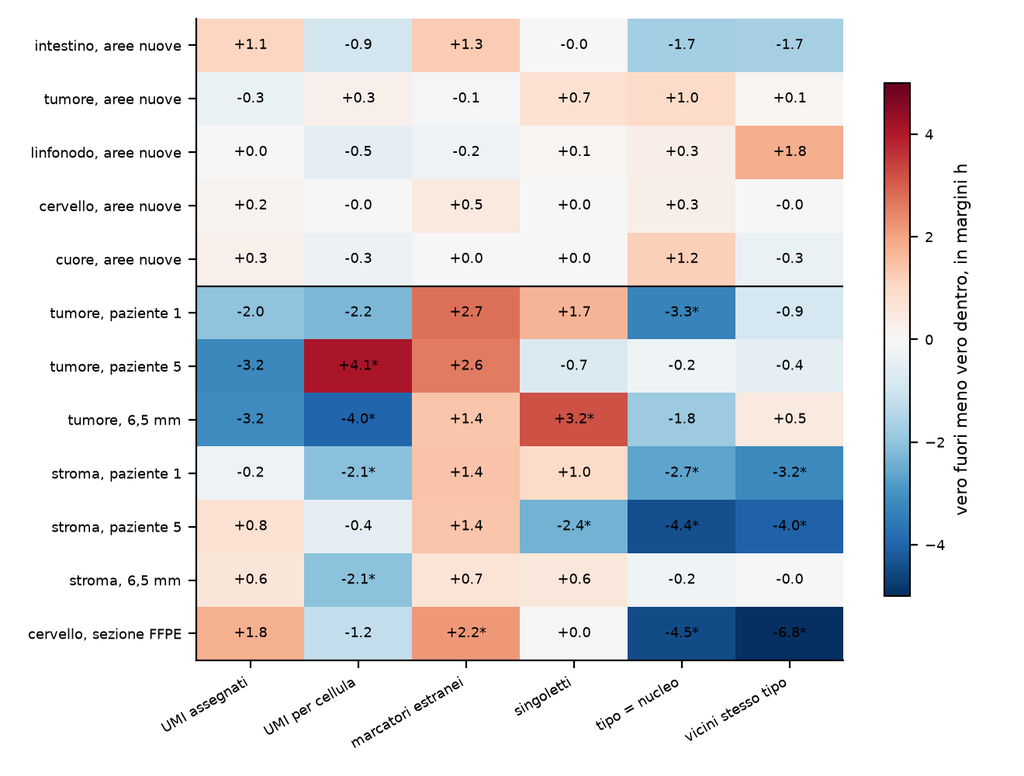

Spostamento del vero, media fuori meno media dentro campione, in margini h; asterisco: spostamento smentito con la regola V. **Cosa guardare**: sopra la riga (stesse sezioni) quasi tutto chiaro; sotto (altri pazienti e sezioni) celle scure, fino a 7 margini.

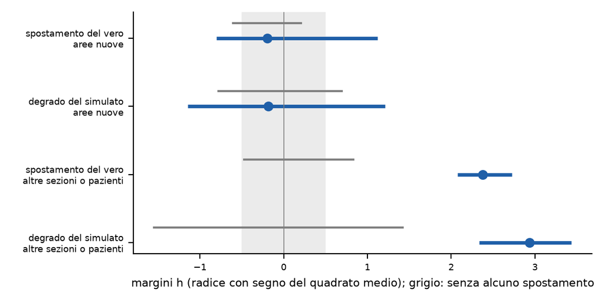

Stime aggregate (radice con segno del quadrato medio, DEC-098) con intervallo al 95 %; in grigio l’intervallo che si avrebbe senza alcuno spostamento; fascia: ±0,5 h. **Cosa guardare**: nelle stesse sezioni le stime stanno dentro il grigio; negli altri pazienti e sezioni ben fuori, oltre 2 margini.

# Correzioni

1. **Distribuzione nulla del modello t** (trovata guardando la figura 3, poi confermata dalla revisione statistica): la funzione riduceva ogni insieme a un solo valore, e gli stimatori quadratici sottraevano una varianza troppo grande; i soli intervalli «senza spostamento» di L2 erano sbagliati (tutti negativi). Corretta conservando le numerosità; stime, intervalli ed esiti non cambiano.
2. **StarDist sulle aree di 500 µm** (G-3): vedi sopra.
3. **Esportazioni duplicate**: durante il calcolo 24 esportazioni di aree di taratura a pannello intero (servite a G-1 d) sono state tolte dalla coda di RCTD, per non rifare calcoli identici a F3.1; 6 erano già partite (5 dell’intestino e A2_r1) e restano come controllo.

# Revisione avversariale

- **Misure** (sotto-agente con codice proprio, `/mnt/micron/geo_spatialtrans/F3.3/review/misure/`): 9 esecuzioni, una per sezione di verifica; allargamento dei nuclei ed etichette trasferite identici nucleo per nucleo; 62 misure su 63 entro 1e-9. Discrepanza: marcatori estranei nel linfonodo (0,616 contro 0,565). Causa: 14 geni sono marcatori di due tipi, e la catena li conta una volta per lista, come F3.1 (BL-264). Il revisore li contava una volta sola; con la stessa lettura torna alla cifra. **Spiegata** con `tools/F3.3_bl264_a4.py`: lo scarto simulato meno vero resta (0,132 con la definizione di F3.1, 0,145 senza i geni doppi). Cambia invece lo spostamento del vero fuori campione: −0,010 contro −0,057, cioè −0,2 contro −1,5 h. Decisione tecnica: resta la definizione di F3.1; quando i marcatori estranei del linfonodo entrano in una decisione, si riportano le due letture (BL-264 chiusa).
- **Statistiche** (sotto-agente con codice proprio, `/mnt/micron/geo_spatialtrans/F3.3/review/stat/`): 2 817 quantità; le deterministiche tornano entro 1e-9, gli intervalli Monte Carlo nell’ordine di grandezza dichiarato. Due discrepanze. (1) La distribuzione nulla di L2 nel commit `711faae`: è la correzione 1, già fatta. (2) **Ambiguità della pre-registrazione**: la regola V usa la deviazione standard combinata con gli insiemi di verifica, mentre il conteggio delle celle scritto in P-3 (17 e 7) usava la sola taratura. Con la sola taratura (`F3.3_sens_insd.py`): P-4 L1 vale 10 su 13 = 0,77, sotto 0,8; P-4 L2 22 su 29; Q_G L1 −0,34 e L2 2,37; P-5 L2 violata. Cambiano tre giudizi dentro campione (UMI assegnati nel tumore, concordanza nel cervello, UMI per cellula nel cuore). Si giudica com’era scritta la regola (deviazione combinata): P-4 L1 confermata, **esito fragile**. In tutte e due le letture nessun difetto cambia segno sulle aree nuove. Quelli che non restano smentiti sono «indeterminati» per precisione: 1 area nel cervello, 3 nel tumore.

# Cosa è girato

Commit della catena e dei risultati: vedi `git log` del ramo `f3-methods` (chiusura «F3.3: …»). Script: `tools/F3.3_areas.py`, `F3.3_segment.py`, `F3.3_stardist.py`, `F3.3_consensus.py`, `F3.3_regions.R`, `F3.3_export.py`, `F3.1_b2c.py`, `F3.1_rctd.R`, `F3.3_holdout_measures.py`, `F3_3_common.py`, `F3_3_stats.py`, `F3.3_analysis.py`, `F3.3_run.sh`, `F3.3_fix_a4.sh`. Semi: RCTD 20261118 (come F3.1), statistiche 20261119-20261121, bootstrap B = 2 000. Processi: 4 (catena), 2 (riproducibilità). md5: 1 669 file identici prima e dopo (`/mnt/micron/geo_spatialtrans/F3.3/md5/`). Registro delle letture dei dati di verifica: `data/holdout/HOLDOUT_LOG.tsv`, prima lettura di L1 e L2.

# Appendice

## Tutte le celle (tessuto × misura × insieme)

| tessuto | misura | insieme | livello | aree | margine h | scarto dentro / h | esito dentro | scarto fuori / h | esito fuori | spostamento / h | esito spostamento |
| --- | --- | --- | --- | --- | --- | --- | --- | --- | --- | --- | --- |
| intestino | M-1 | A1 | L1 | 4 | 0.008309 | +8.05 | smentita | +6.99 | smentita | +1.06 | indeterminata |
| intestino | M-2 | A1 | L1 | 4 | 56.06 | -0.42 | indeterminata | +0.51 | indeterminata | -0.93 | indeterminata |
| intestino | M-3 | A1 | L1 | 4 | 0.01832 | +5.31 | smentita | +4.05 | smentita | +1.25 | indeterminata |
| intestino | M-4 | A1 | L1 | 4 | 0.01 | -3.09 | smentita | -3.08 | smentita | -0.01 | confermata |
| intestino | M-5 | A1 | L1 | 4 | 0.01012 | -1.68 | indeterminata | +0.01 | indeterminata | -1.69 | indeterminata |
| intestino | M-6 | A1 | L1 | 4 | 0.009995 | -8.99 | smentita | -7.32 | smentita | -1.67 | indeterminata |
| tumore del colon | M-1 | A23 | L1 | 3 | 0.02953 | +2.49 | indeterminata | +2.82 | indeterminata | -0.33 | indeterminata |
| tumore del colon | M-1 | CRC_6p5mm_SR410 | L2 | 5 | 0.02953 | +2.49 | indeterminata | +5.65 | smentita | -3.16 | indeterminata |
| tumore del colon | M-1 | CRC_P1_SR300 | L2 | 4 | 0.02953 | +2.49 | indeterminata | +4.49 | smentita | -2.00 | indeterminata |
| tumore del colon | M-1 | CRC_P5_SR300 | L2 | 3 | 0.02953 | +2.49 | indeterminata | +5.70 | smentita | -3.21 | indeterminata |
| tumore del colon | M-2 | A23 | L1 | 3 | 214.4 | -0.11 | indeterminata | -0.38 | indeterminata | +0.26 | indeterminata |
| tumore del colon | M-2 | CRC_6p5mm_SR410 | L2 | 5 | 214.4 | -0.11 | indeterminata | +3.85 | smentita | -3.96 | smentita |
| tumore del colon | M-2 | CRC_P1_SR300 | L2 | 4 | 214.4 | -0.11 | indeterminata | +2.12 | smentita | -2.24 | indeterminata |
| tumore del colon | M-2 | CRC_P5_SR300 | L2 | 3 | 214.4 | -0.11 | indeterminata | -4.20 | smentita | +4.09 | smentita |
| tumore del colon | M-3 | A23 | L1 | 3 | 0.01151 | +8.14 | smentita | +8.21 | smentita | -0.07 | indeterminata |
| tumore del colon | M-3 | CRC_6p5mm_SR410 | L2 | 5 | 0.01151 | +8.14 | smentita | +6.76 | smentita | +1.38 | indeterminata |
| tumore del colon | M-3 | CRC_P1_SR300 | L2 | 4 | 0.01151 | +8.14 | smentita | +5.39 | smentita | +2.75 | indeterminata |
| tumore del colon | M-3 | CRC_P5_SR300 | L2 | 3 | 0.01151 | +8.14 | smentita | +5.54 | smentita | +2.60 | indeterminata |
| tumore del colon | M-4 | A23 | L1 | 3 | 0.014 | -9.97 | smentita | -10.72 | smentita | +0.75 | indeterminata |
| tumore del colon | M-4 | CRC_6p5mm_SR410 | L2 | 5 | 0.014 | -9.97 | smentita | -13.16 | smentita | +3.19 | smentita |
| tumore del colon | M-4 | CRC_P1_SR300 | L2 | 4 | 0.014 | -9.97 | smentita | -11.68 | smentita | +1.71 | indeterminata |
| tumore del colon | M-4 | CRC_P5_SR300 | L2 | 3 | 0.014 | -9.97 | smentita | -9.23 | smentita | -0.74 | indeterminata |
| tumore del colon | M-5 | A23 | L1 | 3 | 0.0034 | -18.49 | smentita | -19.46 | smentita | +0.97 | indeterminata |
| tumore del colon | M-5 | CRC_6p5mm_SR410 | L2 | 5 | 0.0034 | -18.49 | smentita | -16.68 | smentita | -1.81 | indeterminata |
| tumore del colon | M-5 | CRC_P1_SR300 | L2 | 4 | 0.0034 | -18.49 | smentita | -15.14 | smentita | -3.34 | smentita |
| tumore del colon | M-5 | CRC_P5_SR300 | L2 | 3 | 0.0034 | -18.49 | smentita | -18.29 | smentita | -0.20 | indeterminata |
| tumore del colon | M-6 | A23 | L1 | 3 | 0.01569 | -11.03 | smentita | -11.11 | smentita | +0.08 | indeterminata |
| tumore del colon | M-6 | CRC_6p5mm_SR410 | L2 | 5 | 0.01569 | -11.03 | smentita | -11.50 | smentita | +0.47 | indeterminata |
| tumore del colon | M-6 | CRC_P1_SR300 | L2 | 4 | 0.01569 | -11.03 | smentita | -10.13 | smentita | -0.90 | indeterminata |
| tumore del colon | M-6 | CRC_P5_SR300 | L2 | 3 | 0.01569 | -11.03 | smentita | -10.60 | smentita | -0.43 | indeterminata |
| stroma | M-1 | CRC_6p5mm_SR410 | L2 | 3 | 0.1617 | -1.03 | indeterminata | -1.65 | indeterminata | +0.62 | indeterminata |
| stroma | M-1 | CRC_P1_SR300 | L2 | 3 | 0.1617 | -1.03 | indeterminata | -0.79 | indeterminata | -0.24 | indeterminata |
| stroma | M-1 | CRC_P5_SR300 | L2 | 1 | 0.1617 | -1.03 | indeterminata | -1.81 | indeterminata | +0.78 | indeterminata |
| stroma | M-2 | CRC_6p5mm_SR410 | L2 | 3 | 216.7 | -0.04 | confermata | +2.02 | smentita | -2.06 | smentita |
| stroma | M-2 | CRC_P1_SR300 | L2 | 3 | 216.7 | -0.04 | confermata | +2.06 | smentita | -2.10 | smentita |
| stroma | M-2 | CRC_P5_SR300 | L2 | 1 | 216.7 | -0.04 | confermata | +0.40 | indeterminata | -0.44 | indeterminata |
| stroma | M-3 | CRC_6p5mm_SR410 | L2 | 3 | 0.07076 | +1.93 | smentita | +1.23 | indeterminata | +0.69 | indeterminata |
| stroma | M-3 | CRC_P1_SR300 | L2 | 3 | 0.07076 | +1.93 | smentita | +0.52 | indeterminata | +1.41 | indeterminata |
| stroma | M-3 | CRC_P5_SR300 | L2 | 1 | 0.07076 | +1.93 | smentita | +0.56 | indeterminata | +1.37 | indeterminata |
| stroma | M-4 | CRC_6p5mm_SR410 | L2 | 3 | 0.01403 | -9.75 | smentita | -10.33 | smentita | +0.58 | indeterminata |
| stroma | M-4 | CRC_P1_SR300 | L2 | 3 | 0.01403 | -9.75 | smentita | -10.72 | smentita | +0.97 | indeterminata |
| stroma | M-4 | CRC_P5_SR300 | L2 | 1 | 0.01403 | -9.75 | smentita | -7.38 | smentita | -2.37 | smentita |
| stroma | M-5 | CRC_6p5mm_SR410 | L2 | 3 | 0.03261 | -2.53 | smentita | -2.30 | smentita | -0.23 | indeterminata |
| stroma | M-5 | CRC_P1_SR300 | L2 | 3 | 0.03261 | -2.53 | smentita | +0.12 | indeterminata | -2.66 | smentita |
| stroma | M-5 | CRC_P5_SR300 | L2 | 1 | 0.03261 | -2.53 | smentita | +1.88 | indeterminata | -4.41 | smentita |
| stroma | M-6 | CRC_6p5mm_SR410 | L2 | 3 | 0.0421 | -5.63 | smentita | -5.61 | smentita | -0.03 | confermata |
| stroma | M-6 | CRC_P1_SR300 | L2 | 3 | 0.0421 | -5.63 | smentita | -2.46 | smentita | -3.18 | smentita |
| stroma | M-6 | CRC_P5_SR300 | L2 | 1 | 0.0421 | -5.63 | smentita | -1.59 | indeterminata | -4.04 | smentita |
| linfonodo (500 µm) | M-1 | A4 | L1 | 2 | 0.01738 | +1.24 | indeterminata | +1.23 | indeterminata | +0.01 | indeterminata |
| linfonodo (500 µm) | M-2 | A4 | L1 | 2 | 41.12 | -0.58 | indeterminata | -0.10 | indeterminata | -0.48 | indeterminata |
| linfonodo (500 µm) | M-3 | A4 | L1 | 2 | 0.03928 | +3.36 | smentita | +3.60 | smentita | -0.24 | indeterminata |
| linfonodo (500 µm) | M-4 | A4 | L1 | 2 | 0.01 | -0.57 | confermata | -0.68 | confermata | +0.10 | confermata |
| linfonodo (500 µm) | M-5 | A4 | L1 | 2 | 0.1183 | -0.54 | indeterminata | -0.86 | indeterminata | +0.32 | indeterminata |
| linfonodo (500 µm) | M-6 | A4 | L1 | 2 | 0.05137 | -2.37 | smentita | -4.18 | smentita | +1.81 | indeterminata |
| cervello | M-1 | A5 | L1 | 1 | 0.06319 | -0.60 | indeterminata | -0.79 | indeterminata | +0.19 | indeterminata |
| cervello | M-1 | MouseBrain_FFPE_SR401 | L2 | 4 | 0.06319 | -0.60 | indeterminata | -2.38 | smentita | +1.78 | indeterminata |
| cervello | M-2 | A5 | L1 | 1 | 2515 | -0.47 | confermata | -0.45 | indeterminata | -0.02 | confermata |
| cervello | M-2 | MouseBrain_FFPE_SR401 | L2 | 4 | 2515 | -0.47 | confermata | +0.77 | indeterminata | -1.23 | indeterminata |
| cervello | M-3 | A5 | L1 | 1 | 0.03948 | +2.25 | smentita | +1.76 | indeterminata | +0.49 | indeterminata |
| cervello | M-3 | MouseBrain_FFPE_SR401 | L2 | 4 | 0.03948 | +2.25 | smentita | +0.07 | confermata | +2.18 | smentita |
| cervello | M-4 | A5 | L1 | 1 | 0.01 | +0.04 | confermata | +0.01 | confermata | +0.02 | confermata |
| cervello | M-4 | MouseBrain_FFPE_SR401 | L2 | 4 | 0.01 | +0.04 | confermata | -0.01 | confermata | +0.05 | confermata |
| cervello | M-5 | A5 | L1 | 1 | 0.0137 | -0.10 | indeterminata | -0.41 | indeterminata | +0.31 | indeterminata |
| cervello | M-5 | MouseBrain_FFPE_SR401 | L2 | 4 | 0.0137 | -0.10 | indeterminata | +4.37 | smentita | -4.47 | smentita |
| cervello | M-6 | A5 | L1 | 1 | 0.02092 | +2.33 | smentita | +2.36 | indeterminata | -0.04 | indeterminata |
| cervello | M-6 | MouseBrain_FFPE_SR401 | L2 | 4 | 0.02092 | +2.33 | smentita | +9.15 | smentita | -6.83 | smentita |
| cuore | M-1 | A6 | L1 | 5 | 0.03586 | -0.54 | indeterminata | -0.80 | indeterminata | +0.27 | indeterminata |
| cuore | M-2 | A6 | L1 | 5 | 73 | -0.09 | confermata | +0.22 | confermata | -0.31 | indeterminata |
| cuore | M-3 | A6 | L1 | 5 | 0.0503 | +0.47 | indeterminata | +0.47 | indeterminata | +0.00 | indeterminata |
| cuore | M-4 | A6 | L1 | 5 | 0.01 | +0.00 | confermata | +0.00 | confermata | +0.00 | confermata |
| cuore | M-5 | A6 | L1 | 5 | 0.02066 | -0.28 | indeterminata | -1.49 | indeterminata | +1.20 | indeterminata |
| cuore | M-6 | A6 | L1 | 5 | 0.06547 | -0.64 | indeterminata | -0.32 | confermata | -0.32 | indeterminata |

## Componenti di varianza fra pazienti e fra aree

| tessuto | measure | groups | n | sigma_patient | sigma_area | rho | lo | hi | verdict |
| --- | --- | --- | --- | --- | --- | --- | --- | --- | --- |
| tumore del colon | M-1 | P1-P2-P5 | 8,4,3 | 0.046 | 0.028 | 1.649 | 0.0 | 3.776 | indeterminata |
| tumore del colon | M-1 | con 6,5 mm | 8,4,3,5 | 0.041 | 0.054 | 0.757 | 0.0 | 1.688 | indeterminata |
| tumore del colon | M-2 | P1-P2-P5 | 8,4,3 | 583.423 | 216.094 | 2.7 | 0.0 | 6.177 | indeterminata |
| tumore del colon | M-2 | con 6,5 mm | 8,4,3,5 | 656.293 | 194.829 | 3.369 | 0.769 | 6.911 | smentita |
| tumore del colon | M-3 | P1-P2-P5 | 8,4,3 | 0.017 | 0.021 | 0.822 | 0.0 | 2.041 | indeterminata |
| tumore del colon | M-3 | con 6,5 mm | 8,4,3,5 | 0.013 | 0.021 | 0.613 | 0.0 | 1.434 | indeterminata |
| tumore del colon | M-4 | P1-P2-P5 | 8,4,3 | 0.014 | 0.01 | 1.427 | 0.0 | 3.281 | indeterminata |
| tumore del colon | M-4 | con 6,5 mm | 8,4,3,5 | 0.023 | 0.009 | 2.565 | 0.525 | 5.269 | smentita |
| tumore del colon | M-5 | P1-P2-P5 | 8,4,3 | 0.007 | 0.005 | 1.294 | 0.0 | 2.973 | indeterminata |
| tumore del colon | M-5 | con 6,5 mm | 8,4,3,5 | 0.005 | 0.005 | 1.046 | 0.0 | 2.227 | indeterminata |
| tumore del colon | M-6 | P1-P2-P5 | 8,4,3 | 0.005 | 0.013 | 0.413 | 0.0 | 1.319 | indeterminata |
| tumore del colon | M-6 | con 6,5 mm | 8,4,3,5 | 0.006 | 0.014 | 0.452 | 0.0 | 1.168 | indeterminata |
| stroma | M-1 | P1-P2-P5 | 5,3,1 | 0.0 | 0.116 | 0.0 | 0.0 | 1.614 | indeterminata |
| stroma | M-1 | con 6,5 mm | 5,3,1,3 | 0.038 | 0.1 | 0.38 | 0.0 | 1.514 | indeterminata |
| stroma | M-2 | P1-P2-P5 | 5,3,1 | 271.09 | 94.687 | 2.863 | 0.0 | 8.157 | indeterminata |
| stroma | M-2 | con 6,5 mm | 5,3,1,3 | 257.365 | 89.799 | 2.866 | 0.431 | 6.936 | indeterminata |
| stroma | M-3 | P1-P2-P5 | 5,3,1 | 0.063 | 0.029 | 2.2 | 0.0 | 6.323 | indeterminata |
| stroma | M-3 | con 6,5 mm | 5,3,1,3 | 0.049 | 0.026 | 1.863 | 0.0 | 4.688 | indeterminata |
| stroma | M-4 | P1-P2-P5 | 5,3,1 | 0.018 | 0.005 | 3.935 | 0.0 | 11.212 | indeterminata |
| stroma | M-4 | con 6,5 mm | 5,3,1,3 | 0.014 | 0.004 | 3.466 | 0.67 | 8.401 | smentita |
| stroma | M-5 | P1-P2-P5 | 5,3,1 | 0.069 | 0.022 | 3.158 | 0.0 | 9.053 | indeterminata |
| stroma | M-5 | con 6,5 mm | 5,3,1,3 | 0.057 | 0.022 | 2.559 | 0.32 | 6.26 | indeterminata |
| stroma | M-6 | P1-P2-P5 | 5,3,1 | 0.094 | 0.021 | 4.479 | 0.366 | 12.783 | indeterminata |
| stroma | M-6 | con 6,5 mm | 5,3,1,3 | 0.08 | 0.02 | 4.07 | 0.842 | 9.791 | smentita |

## Da dove vengono i numeri del riassunto

| frase del riassunto | fonte | valore letto |
| --- | --- | --- |
| 38 aree vere mai usate; 15 nuove nelle stesse sezioni | `results/F3.3/F3.3_areas.csv` (level L1, L2) | 15 L1, 23 L2 |
| nelle stesse sezioni nessuno spostamento né degrado rilevato | `F3.3_summary.csv`, P-1 L1, P-3 L1 | −0,20 (−0,81; 1,12); −0,19 (−1,14; 1,21) |
| difetti che restano sulle aree nuove: 10 su 12, i due mancanti nel cervello | `F3.3_summary.csv` P-4 L1; `F3.3_cells.csv` | k = 10, n = 12; A5 M-3, A5 M-6 (1 area) |
| il simulato peggiora di circa tre margini negli altri pazienti | `F3.3_summary.csv`, P-3 L2 | 2,94 (2,33; 3,43) |
| trascritti per cellula nel tumore 1 100, 640, 2 000, 270; simulato altrettanti | `F3.3_area_values.csv`, media per insieme di M2 | 1 120; 640; 1 997; 270; simulato 1 096 |
| cervello FFPE un terzo | `F3.3_area_values.csv` | 1 417 contro 4 514 |
| conferma costruita che cade in 2 sezioni su 3 dello stroma | `F3.3_summary.csv` P-5 L2 | A3 M-2 in tumore da 6,5 mm e P1 |
| 4 combinazioni su 12 con variabilità fra sezioni non trascurabile | `F3.3_varcomp.csv`, gruppi «con 6,5 mm» | A2 M-2, A2 M-4, A3 M-4, A3 M-6 smentite |
| vicini dello stesso tipo 89 %, 72-75 %, 65 % | `F3.3_area_values.csv`, M6 nello stroma | P2 0,886; P1 0,752; P5 0,716; simulato 0,649 |
| cuore 0,11 contro 0,10 | `F3.3_summary.csv` CP-1; `F3.1_PH5_aniso_diff.csv` | 0,112; 0,0967 |
| falso fuori campione senza spostamento | `F3.3_summary.csv` CP-2 | 0,007 |
| 18 valori veri su 228 | `F3.3_summary.csv` P-7 | 18 su 228 |
| profondità fino a 7 volte | `F3.3_area_values.csv` | tumore 1 997 / 270 = 7,4 |
| tempi: circa 2 ore con 4 processi; riproducibilità circa 1 ora con 2 | orari dei lavori sul server | 18:48-20:50; 20:01-20:31 più correzione 20:39 |